# ISYE6420 Homework 3

```python
import numpy as np
from scipy.stats import beta, norm
from scipy.optimize import fsolve
import matplotlib.pyplot as plt
```

## Question 1c

Calculate HPD 95% The pdf must evaluate to the same density at each bound (so k is horizontal).

The probability within those bounds must be equal to 1 - alpha.

Beta **PDF:** $f(x | \alpha, \beta) = \frac{x^{\alpha - 1}(1 - x)^{\beta - 1}}{B(\alpha, \beta)}$

```python
guess_lwr, guess_upr = 0.6, 0.95
a, b = 53.5, 11.5
def credible_interval(x, a, b, dist):
    alpha = 0.05
    lwr, upr = x

    cond_1 = dist.pdf(upr, a, b) - dist.pdf(lwr, a, b)
    cond_2 = (
        dist.cdf(upr, a, b) - dist.cdf(lwr, a, b) - (1 - alpha)
    )
    return cond_1, cond_2

lower, upper = fsolve(credible_interval, (guess_lwr, guess_upr), args=(a, b, beta))
print(f"HDI Credible Interval: [{lower:.2f}, {upper:.2f}]")
print(
    "Probability within set: ", round(beta.cdf(upper, a, b) - beta.cdf(lower, a, b), 2)
    )
print("Width of interval: ", round(upper - lower, 2))
```

```
HDI Credible Interval: [0.73, 0.91]
Probability within set:  0.95
Width of interval:  0.18
```

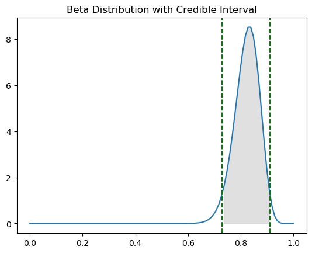

```python
# plot the beta distribution and the credible interval
x = np.linspace(0, 1, 100)
y = beta.pdf(x, a, b)
plt.plot(x, y, label="Beta PDF")
plt.fill_between(x, y, where=(x >= lower) & (x <= upper), color="lightgrey", alpha=0.7, label="Credible Interval")
plt.axvline(lower, color="green", linestyle="--", label=f"Lower Bound: {lower:.2f}")
plt.axvline(upper, color="green", linestyle="--", label=f"Upper Bound: {upper:.2f}")
plt.title("Beta Distribution with Credible Interval")
```

## Question 1d

$$ p_0 = \int_{0.8}^{\inf} \pi(\theta|x)d\theta $$$$ p_1 = \int_{\inf}^{0.8} \pi(\theta|x)d\theta $$

Use the CDF of the Beta function to evaluate the two hypotheses and their associated integrals, producing:

```python
p = 0.8
a = 53.5
b = 11.5

prob_left = beta.cdf(p, a, b)
prob_right = 1 - prob_left
print(f"Probability of observing a value < {p}: {prob_left:.2f}")
print(f"Probability of observing a value >= {p}: {prob_right:.2f}")
```

```
Probability of observing a value < 0.8: 0.29
Probability of observing a value >= 0.8: 0.71
```

## Question 2

Assuming the prior also has a normal distribution: $$ \pi(\theta|\mu) \sim N(\mu, \tau^2) $$ $$ f(X|\theta) \sim N(\theta, (0.02)^2) $$ First we find the marginal likelihood for $x_i$ $$ m_i(x_i|\mu) = \int f_i(x_i,\theta_i)\pi(\theta|\mu)d\theta_i $$ $$ m(x|\mu) = \prod_{i=1}^n m_i(x_i|\mu) $$ Since $X_i$ distributions are all independent and identically distributed, the variances can simply be added: $$ X_i \sim_{iid} N(\mu, \sigma^2+\tau^2) $$ Hence: $$ m(x|\mu) = \prod_{i=1}^n\frac{1}{\sqrt{2\pi(\sigma^2+\tau^2)}}e^{\frac{-(x_i-\mu)^2}{2(\sigma^2+\tau^2)}} $$

```python
readings = [3.29, 3.31, 3.35, 3.34, 3.28]
# Mean
mean_reading = np.mean(readings)
print(f"Mean of readings: {mean_reading:.3f}")
# Sample Variance
variance_reading = np.var(readings, ddof=1)
print(f"Variance of readings: {variance_reading:.4f}")
# Standard Deviation
std_dev_reading = np.sqrt(variance_reading)
print(f"Standard Deviation of readings: {std_dev_reading:.4f}")
```

```
Mean of readings: 3.314
Variance of readings: 0.0009
Standard Deviation of readings: 0.0305
```

```python
sigma = 0.02
s = std_dev_reading
n = len(readings)
B_hat = sigma**2 / s**2
print(f"Estimated weighting factor B: {B_hat:.4f}")
```

```
Estimated weighting factor B: 0.4301
```

To find $\theta_6$ distribution given $x_6 = 3.30$:

```python
def posterior_mean(B, x_bar, new_x):
    return B*x_bar + (1-B)*new_x

new_x = 3.30
post_mean = posterior_mean(B_hat, mean_reading, new_x)
print(f"Posterior mean for new reading: {post_mean:.4f}")

def posterior_variance(B, sigma):
    return (1-B) * sigma**2
post_var = posterior_variance(B_hat, sigma)
print(f"Posterior variance for new reading: {post_var:.6f}")
```

```
Posterior mean for new reading: 3.3060
Posterior variance for new reading: 0.000228
```

Finding the 95% HDI credible set:

```python
guess_lwr, guess_upr = 3.28, 3.33
a, b = post_mean, post_var**0.5

lower, upper = fsolve(credible_interval, (guess_lwr, guess_upr), args=(a, b, norm))
print(f"HDI Credible Interval: [{lower:.2f}, {upper:.2f}]")
print(
    "Probability within set: ", round(norm.cdf(upper, a, b) - norm.cdf(lower, a, b), 2)
    )
print("Width of interval: ", round(upper - lower, 2))
```

```
HDI Credible Interval: [3.28, 3.34]
Probability within set:  0.95
Width of interval:  0.06
```

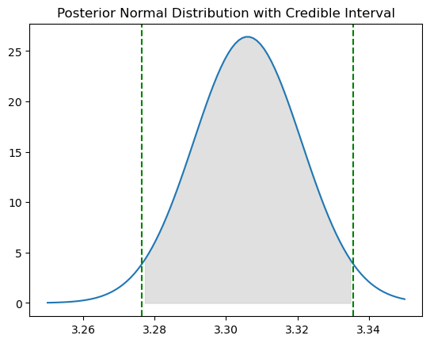

```python
# Plotting the distribution and the credible interval
x = np.linspace(3.25, 3.35, 100)
y = norm.pdf(x, a, b)
plt.plot(x, y, label="Posterior Normal PDF")
plt.fill_between(x, y, where=(x >= lower) & (x <= upper), color="lightgrey", alpha=0.7, label="Credible Interval")
plt.axvline(lower, color="green", linestyle="--", label=f"Lower Bound: {lower:.2f}")
plt.axvline(upper, color="green", linestyle="--", label=f"Upper Bound: {upper:.2f}")
plt.title("Posterior Normal Distribution with Credible Interval")
```

# Question 3

Parasol mushroom distribution $\sim N(\mu, 9)$

Likelihood: $f(x|\mu=17,n=10) \sim N(17, \frac{\sigma}{10})$

Prior: $\pi(x) \sim N(18, \sigma^2)$

As we are testing for a precise null in a continuous distribution, we need to use a point mass. $$ \pi(\mu) = \pi_0\delta_{18} + \pi_1\xi(\mu)=0.8\delta_{18} + 0.2\xi(\mu) $$ where $\pi_0 + \pi_1 = 1$.

The spread distribution can be described as: $ξ(μ) = \frac{1}{\sqrt{2π·12}} e^{-\frac{(μ−18)^2}{2·12}}$. From the known normal distribution pdf, we can infer that the spread variation is 12 and the spread mean is 18.

```python
measured_mu = 17
n=10
known_var = 9

# Test hypotheses for mu
h1_mu = 18

# Spread distribution for mu under H1
spread_var = 12
spread_mu = 18

measured_likelihood = norm.pdf(measured_mu, loc=measured_mu, scale=np.sqrt(known_var/n))

def spread_dist(mu, spread_var):
    return norm.pdf(mu, loc=18, scale=np.sqrt(spread_var))

def likelihood_func(x, mu, known_var, n):
    return norm.pdf(x, loc=mu, scale=np.sqrt(known_var/n))

def marginal_likelihood(x, var):
    return norm.pdf(x, loc=18, scale=np.sqrt(var))

marginal_var = known_var/n + spread_var
bayes_factor_10 = marginal_likelihood(measured_mu, marginal_var) / likelihood_func(measured_mu, h1_mu, known_var, n)
bayes_factor_01 = 1 / bayes_factor_10
print(f"Bayes Factor in favour of H1: {bayes_factor_10:.3f}")
print(f"Bayes Factor in favour of H0: {bayes_factor_01:.3f}")
```

```
Bayes Factor in favour of H1: 0.443
Bayes Factor in favour of H0: 2.258
```

```python
pi_0 = 0.8

def posterior_prob(bf, pi_0):
    return (1+((1-pi_0)/pi_0) *bf)**(-1)

print(f"Posterior probability of H0: {posterior_prob(bayes_factor_10, pi_0):.3f}")
print(f"Posterior probability of H1: {1 - posterior_prob(bayes_factor_10, pi_0):.3f}")
# Taking the log10 of the Bayes factor for better interpretability
log_bayes_factor_01 = np.log10(bayes_factor_01)
print(f"Log10 of Bayes Factor in favour of H0: {log_bayes_factor_01:.3f}")
log_bayes_factor_10 = np.log10(bayes_factor_10)
print(f"Log10 of Bayes Factor in favour of H1: {log_bayes_factor_10:.3f}")
```

```
Posterior probability of H0: 0.900
Posterior probability of H1: 0.100
Log10 of Bayes Factor in favour of H0: 0.354
Log10 of Bayes Factor in favour of H1: -0.354
```